# Variable Selection: Subsets

# Discussion

## Forward stepwise selection

If there are $p$ predictors (really available model terms, but I’ll expand on that later), $x_1, x_2, ... , x_p$, the algorithm is:

1. Fit all models with just one predictor (specifically, where we only estimate the intercept and one other coefficient). Choose the one with the highest $R^2$ lowest training RMSE. Call that model $M_1$.
2. Keep the predictor from $M_1$ and fit all the models with two predictors (intercept and two other coefficients). Choose the best of these using $R^2$ or training RMSE and call this $M_2$.
3. Continue until all variables have been added. There will be p models, $M_1, ..., M_p$.
4. Choose the best of these $p$ models using cross validation. **NOTE**, when using cross validation, steps 1-3 are done within the folds. So, each fold of cross-validation may actually choose slightly different models for each of $M_1, ..., M_p$. That’s ok! We are using cross-validation to help us find the “best” number of predictor variables to use in the model.
5. Once a decision is made on the optimal number of predictors using cross-validation, use forward selection on the *entire* training sample to fit the final model. We will see that the `caret` package will make this easy for us.

## Questions

1. In groups, go to the board and draw a graphic of how you would implement this algorithm, assuming you could use R but didn’t have `caret`. Be specific about how to divide your data, where model fitting occurs, and how you decide a best model. Assume you have 5 quantitative predictor variables.
2. How should we handle categorical variables in this process? What “problem” to they pose?
3. What do you suppose backward selection is? Do you think it would lead to the same results as forward selection?

# Exercises

We are once again going to use the `cars2018` data. We’ll start by splitting it into the training and testing datasets.

```r
cars2018 <- read_csv("https://raw.githubusercontent.com/juliasilge/supervised-ML-case-studies-course/master/data/cars2018.csv")
set.seed(345)
cars_split <- initial_split(cars2018, prop = .7)
cars_train <- training(cars_split)
cars_test <- testing(cars_split)
```

1. In the first exercise, we are only going to use the quantitative predictor variables to try to predict `MPG`. I have created that dataset, `cars_train_num` below.

```r
cars_train_num <- cars_train %>%
  select(-`Model Index`) %>%
  select_if(is.numeric)
```

Just as a reminder, the graphs below show distributions of the quantitative variables in the datatset.

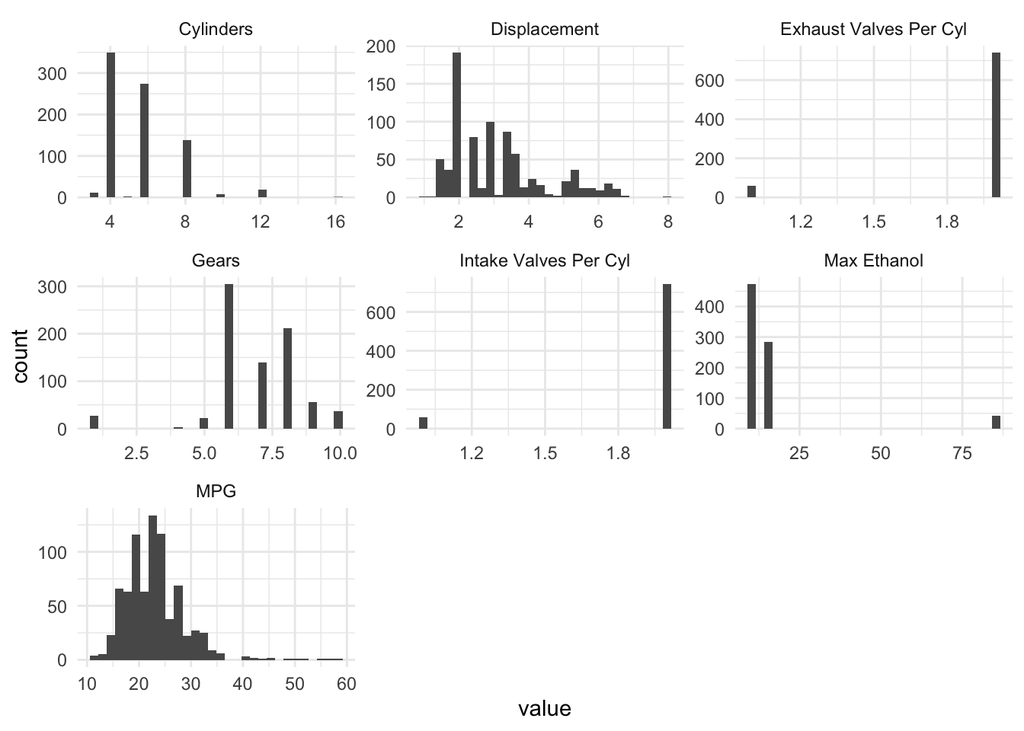

```r
cars_train_num %>%
  pivot_longer(cols = everything(),names_to = "variable", values_to = "value") %>%
  ggplot(aes(x = value)) +
  geom_histogram() +
  facet_wrap(vars(variable), scales = "free")
```

You will work with the people at your table to go through the forward stepwise selection process “by hand” for the particular test fold I assign you. We are going to use the “by hand” cross-validation splitting we used last time, but just with the `cars_train_num` dataset. This variable can have up to 6 variables. For the test fold assigned to you, you should do the following:

1. Find the “best” model with 1 variable, 2 variables, …., 6 variables using the data without the test fold.
2. For each of the 6 “best” models, compute the RMSE on your assigned test fold (see the 03_Linear_Model_k_fold_cv file if you need to remember details on how to do this).
3. Record each of your 6 models and their test RMSE in the corresponding rows in this [spreadsheet](https://docs.google.com/spreadsheets/d/18GtOreKU79fHnf1ZfsaG8CXy7KEUUmsvWyTq10PQv9g/edit?usp=sharing).

```r
fold1_obs <- c(4,6,8,17,23,25,27,28,35,41,45,47,49,57,60,65,70,75,76,82,99,101,107,111,113,115,116,118,121,126,133,136,161,164,184,185,190,191,192,196,201,203,209,213,219,226,229,231,234,236,241,243,244,246,247,259,266,268,271,276,282,291,293,295,297,301,302,305,308,311,312,315,317,327,328,330,332,335,338,341,353,361,370,374,375,376,381,387,389,395,396,403,412,417,421,440,453,460,470,479,480,497,502,505,508,513,515,518,530,532,537,546,549,551,556,560,564,568,572,579,582,585,588,598,612,614,617,622,624,628,634,635,637,638,639,643,644,647,656,657,671,672,677,693,695,702,705,708,711,723,724,734,751,764,765,768,782,795,797,798,801)

fold2_obs <- c(1,3,16,18,20,22,29,30,40,43,46,53,68,72,74,79,83,91,95,97,98,100,102,105,114,125,130,131,134,135,139,140,145,149,150,152,165,167,173,174,178,193,200,204,205,216,221,242,249,256,264,270,280,283,290,303,318,319,321,323,336,342,343,346,350,351,362,366,367,373,378,379,380,382,393,398,399,401,405,408,413,419,429,439,442,443,444,445,465,471,476,478,483,486,492,493,498,499,501,506,512,520,522,527,533,534,535,538,540,542,545,548,555,557,561,565,575,576,578,580,581,586,595,597,599,602,604,605,606,615,621,640,642,651,661,663,669,670,674,682,683,686,687,701,704,713,719,727,731,733,736,737,741,743,762,770,777,796,800)

fold3_obs <- c(9,10,12,14,19,33,36,44,51,54,56,61,62,63,64,69,86,103,112,117,119,120,137,144,151,159,162,163,176,179,181,187,194,202,211,214,215,217,218,222,233,235,237,239,248,252,258,261,262,263,273,278,281,284,287,300,306,310,313,314,320,329,339,352,359,390,392,394,397,402,407,409,411,416,418,423,428,430,434,435,436,446,448,449,452,455,461,466,469,474,481,484,495,496,503,507,509,524,525,526,529,531,539,550,553,554,562,569,574,589,591,594,600,601,607,608,609,610,613,616,620,629,630,631,641,646,653,654,658,660,662,664,666,675,685,689,696,703,707,715,717,721,722,729,735,744,745,746,756,761,763,767,769,771,772,773,779,781,791,792)

fold4_obs <- c(2,5,7,24,31,38,42,48,50,55,66,67,78,81,84,89,92,94,96,104,106,109,127,128,129,132,141,143,147,148,153,157,160,170,177,186,188,189,197,198,199,208,212,223,227,230,238,240,251,255,257,260,265,267,269,274,277,279,286,288,292,294,299,304,324,334,340,344,347,348,349,354,355,356,358,365,369,377,384,386,391,404,414,415,420,424,425,427,437,438,441,447,450,456,457,458,459,462,463,473,475,482,488,494,504,514,516,517,519,523,528,541,552,559,563,566,583,587,590,592,593,603,611,625,626,627,633,636,645,649,655,659,673,679,680,698,699,706,709,712,714,720,726,728,730,732,742,747,749,752,753,755,757,776,778,780,783,784,788,790,799)

fold5_obs <- c(11,13,15,21,26,32,34,37,39,52,58,59,71,73,77,80,85,87,88,90,93,108,110,122,123,124,138,142,146,154,155,156,158,166,168,169,171,172,175,180,182,183,195,206,207,210,220,224,225,228,232,245,250,253,254,272,275,285,289,296,298,307,309,316,322,325,326,331,333,337,345,357,360,363,364,368,371,372,383,385,388,400,406,410,422,426,431,432,433,451,454,464,467,468,472,477,485,487,489,490,491,500,510,511,521,536,543,544,547,558,567,570,571,573,577,584,596,618,619,623,632,648,650,652,665,667,668,676,678,681,684,688,690,691,692,694,697,700,710,716,718,725,738,739,740,748,750,754,758,759,760,766,774,775,785,786,787,789,793,794)

#folds - for testing
fold1 <- cars_train_num %>%
  slice(fold1_obs)

fold2 <- cars_train_num %>%
  slice(fold2_obs)

fold3 <- cars_train_num %>%
  slice(fold3_obs)

fold4 <- cars_train_num %>%
  slice(fold4_obs)

fold5 <- cars_train_num %>%
  slice(fold5_obs)

#folds removed - for training
no_fold1 <- cars_train_num %>%
  slice(-fold1_obs)

no_fold2 <- cars_train_num %>%
  slice(-fold2_obs)

no_fold3 <- cars_train_num %>%
  slice(-fold3_obs)

no_fold4 <- cars_train_num %>%
  slice(-fold4_obs)

no_fold5 <- cars_train_num %>%
  slice(-fold5_obs)
```

2. You will be happy to learn that the `caret` package can once again be a great help. The table below is to help remind you of all the arguments in the functions we use most. I have added a new argument, `tuneGrid`.

| function | argument | meaning |
| --- | --- | --- |
| `trainControl` | `method` | sampling method, usually “cv” |
| `trainControl` | `number` | number of folds in cv |
| `train` | `y ~ x1 + ... + xp` | model formula, like in `lm` |
| `train` | `data` | training data after splitting into train and test |
| `train` | `method` | model fitting method |
| `train` | `tuneGrid` | tuning values (in this case # of predictors) |
| `train` | `trControl` | how to split the data, from `trainControl` |
| `train` | `na.action` | how to treat missing values, `na.omit` will remove any row with missing values |

The code below will do just what we did above by hand. It takes less than 5 seconds to run on my computer. We should take a moment to appreciate that! Notice we are using a new method, `leapForward` (from the `leaps` library so make sure you’ve installed that), and a new argument `tuneGrid`. Many algorithms we use will have one or more tuning parameters. In this case, our tuning parameter is the number of terms in the model, `nvmax`.

```r
set.seed(100) #for reproducibility
split <- trainControl(method = "cv", number = 5)

cv_cars_vars <- train(
  MPG ~ .,
  data = cars_train_num,
  method = "leapForward", #NEW method!
  tuneGrid = data.frame(nvmax = 1:6), #NEW argument!
  trControl = split,
  na.action = na.omit
)
```

Let’s check the `summary()` output. Any idea what this is showing?

```r
summary(cv_cars_vars)
```

```
## Subset selection object
## 6 Variables  (and intercept)
##                          Forced in Forced out
## Displacement                 FALSE      FALSE
## Cylinders                    FALSE      FALSE
## Gears                        FALSE      FALSE
## `Max Ethanol`                FALSE      FALSE
## `Intake Valves Per Cyl`      FALSE      FALSE
## `Exhaust Valves Per Cyl`     FALSE      FALSE
## 1 subsets of each size up to 3
## Selection Algorithm: forward
##          Displacement Cylinders Gears `Max Ethanol` `Intake Valves Per Cyl`
## 1  ( 1 ) "*"          " "       " "   " "           " "
## 2  ( 1 ) "*"          " "       "*"   " "           " "
## 3  ( 1 ) "*"          " "       "*"   " "           " "
##          `Exhaust Valves Per Cyl`
## 1  ( 1 ) " "
## 2  ( 1 ) " "
## 3  ( 1 ) "*"
```

This will give us the best tuning parameter, that is the tuning parameter with the smallest cross-validated RMSE. This tells us that 3 predictor variables gives the smallest cross-validated RMSE.

```r
cv_cars_vars$bestTune
```

|  | nvmax |
| --- | --- |
| 3 | 3 |

We can see the cross-validated RMSEs (and some other stats) for all values of `nvmax` in the `results` output.

```r
cv_cars_vars$results
```

|  | nvmax | RMSE | Rsquared | MAE | RMSESD | RsquaredSD | MAESD |
| --- | --- | --- | --- | --- | --- | --- | --- |
| 1 | 1 | 3.901459 | 0.5335032 | 2.520433 | 0.5318762 | 0.05173254 | 0.1621028 |
| 2 | 2 | 3.831246 | 0.5498135 | 2.499391 | 0.5362171 | 0.05649118 | 0.1932975 |
| 3 | 3 | 3.741107 | 0.5694490 | 2.415302 | 0.5137734 | 0.05582753 | 0.1939869 |
| 4 | 4 | 3.743167 | 0.5686848 | 2.415625 | 0.5101661 | 0.05376884 | 0.1826644 |
| 5 | 5 | 3.741370 | 0.5688580 | 2.412308 | 0.5119237 | 0.05340365 | 0.1814053 |
| 6 | 6 | 3.741454 | 0.5690004 | 2.413962 | 0.5112938 | 0.05362825 | 0.1843349 |

The `resample` output shows the fold details only for the best `nvmax`.

```r
cv_cars_vars$resample
```

| RMSE | Rsquared | MAE | Resample |
| --- | --- | --- | --- |
| 4.042937 | 0.5764796 | 2.325590 | Fold1 |
| 3.429961 | 0.5883165 | 2.529971 | Fold3 |
| 3.417292 | 0.5576685 | 2.361162 | Fold2 |
| 4.502482 | 0.4855040 | 2.680862 | Fold5 |
| 3.312865 | 0.6392766 | 2.178926 | Fold4 |

So, summarizing the `resample` results gives the 3-variable row from the `results`:

```r
cv_cars_vars$resample %>%
  summarize(cv_error = mean(RMSE),
            se_cv_error = sd(RMSE))
```

| cv_error | se_cv_error |
| --- | --- |
| 3.741107 | 0.5137734 |

To see the “best” model, we can use the following code, where the id is the best number of variables.

```r
coefficients(cv_cars_vars$finalModel, id = 3)
```

```
##              (Intercept)             Displacement                    Gears
##                42.923635                -3.288085                -0.510874
## `Exhaust Valves Per Cyl`
##                -3.170074
```

Since the last model is fit on the entire training dataset, we would get the same result by fitting the following model:

```r
cv_cars_lm <- lm(MPG ~ Displacement + Gears + `Exhaust Valves Per Cyl`, data = cars_train)

tidy(cv_cars_lm)
```

| term | estimate | std.error | statistic | p.value |
| --- | --- | --- | --- | --- |
| (Intercept) | 42.923635 | 1.43206668 | 29.973209 | 9.023164e-133 |
| Displacement | -3.288085 | 0.12488628 | -26.328630 | 2.042695e-110 |
| Gears | -0.510874 | 0.08476336 | -6.027061 | 2.550798e-09 |
| `Exhaust Valves Per Cyl` | -3.170074 | 0.60323609 | -5.255114 | 1.900694e-07 |

3. Now, use forward stepwise selection with all the variables in the dataset except `Model` and `Model Index`. I’ve included distributions of the categorical variables below as a reminder.

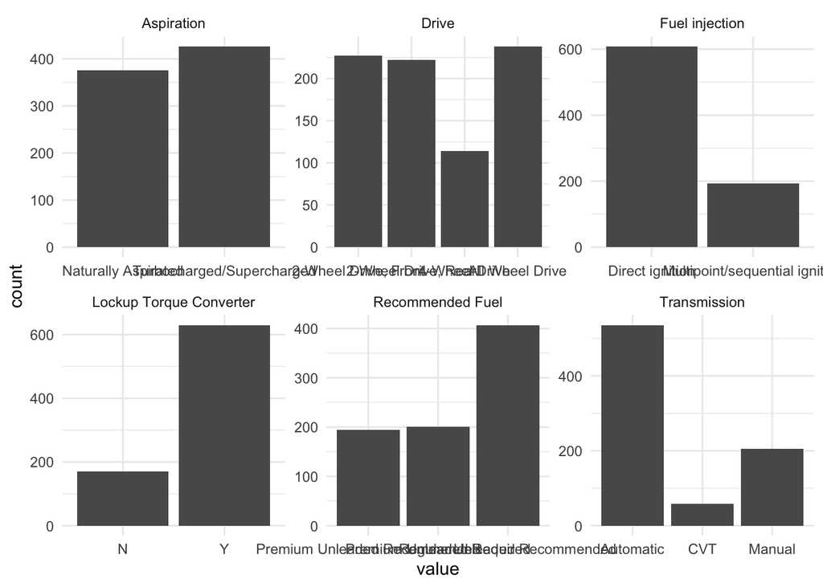

```r
cars_train %>%
  select(-`Model Index`, -Model) %>%
  select_if(is.character) %>%
  pivot_longer(cols = everything(),names_to = "variable", values_to = "value") %>%
  ggplot(aes(x = value)) +
  geom_bar() +
  facet_wrap(vars(variable), scales = "free")
```

1. I’ve started the modeling code for you (delete the `eval=FALSE` before knitting). What is the maximum number of terms that could be included in this model? Why? Make sure to think carefully about what happens to the categorical variables.

```r
set.seed(253)
split <- trainControl(method = "cv", number = 5)

cv_cars_all_vars <- train(
  ___ ~ ___,
  data = ___,
  method = "___",
  tuneGrid = data.frame(nvmax = ___),
  trControl = split,
  na.action = na.omit
)
```

2. What is the best number of terms to include in the model according to cross-validation RMSE?
3. Print the coefficients and variables of the best model.
4. Use the `results` to create a line graph that plots the number of variables on the x-axis and RMSE on the y-axis. Add two more lines that are RMSE + RMSESD and RMSE - RMSESD on the y-axis and still number of variables on the x-axis.
5. Given what you see in the graph above, might you choose fewer variables? Why or why not?
6. Look at the “best” model with only two variables (use `id=2` in the `coefficient()` function. What is odd about this model? In general, how would you approach including only some indicator variables from a categorical variable but not all?
4. Try using backward stepwise selection (`leapBackward`) using all the variables except `Model` and `Model Index`. Do you get the same results as when you use forward selection? Show just enough detail from the output so that you can compare to the results of forward selection.